# tree_orderer

hirgh815

## ape rotateConstr()

The rotateConstr() function rotates internal nodes to find the closest possible match to the desired_order vector without altering the underlying tree topology (i.e., it doesn’t change who is related to whom, just how it’s visualized).

```r
#install.packages("ape")
library(ape)

# Create a random tree with 5 tips
set.seed(42)
my_tree <- rtree(5, tip.label = c("A", "B", "C", "D", "E"))

# Let's see the current tip order
my_tree$tip.label
```

```
## [1] "A" "B" "D" "C" "E"
```

```r
# Output is: "A" "B" "C" "D" "E" (but visual order depends on topology)

# Define your desired target order
desired_order <- c("E", "C", "A", "D", "B")

# Reorder the tree topology to match the constraint
reordered_tree <- rotateConstr(my_tree, desired_order)

# Check the new visual tip order
reordered_tree$tip.label
```

```
## [1] "A" "B" "D" "C" "E"
```

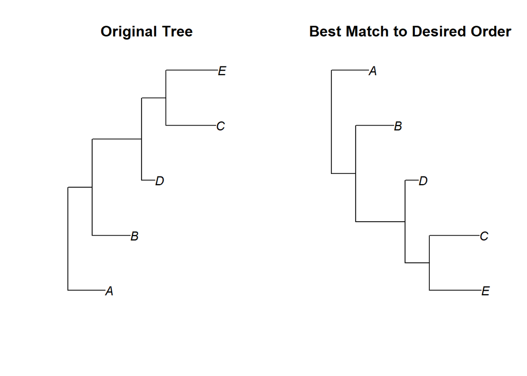

```r
par(mfrow = c(1, 2)) # Side-by-side plotting

# Original Tree
plot(my_tree, main = "Original Tree")

# Reordered Tree
plot(reordered_tree, main = "Best Match to Desired Order")
```

## dendextend rotate()

At every internal node, you look at its two children. You check both orientations (Left-Right vs. Right-Left) and calculate which orientation minimizes the distance to your target list. You save the best choice and move up to the parent node. Using dendextend actually solves the optimal leaf ordering problem for hierarchical clustering rather than general phylogenetic trees.

```r
#install.packages("dendextend")
library(dendextend)
#library(ape)

is.ultrametric(my_tree)
```

```
## [1] FALSE
```

```r
# FALSE

# Force ultrametricity
ultra_tree <- chronos(my_tree)
```

```
##
## Setting initial dates...
## Fitting in progress... get a first set of estimates
##          (Penalised) log-lik = -6.628175
## Optimising rates... dates... -6.628175
## Optimising rates... dates... -6.614573
##
## log-Lik = -7.332859
## PHIIC = 39.95
```

```r
is.ultrametric(ultra_tree)
```

```
## [1] TRUE
```

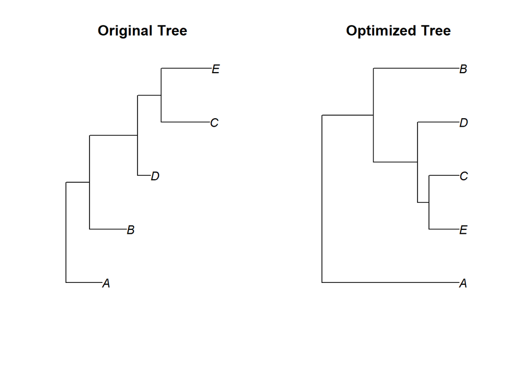

```r
# TRUE

# 1. Convert your phylo tree to a dendrogram
dend <- as.dendrogram(as.hclust(ultra_tree))

# 2. Reorder based on your target vector
# (dendextend automatically uses optimal leaf ordering)
target_order <- c("E","C","A","D","B")

optimized_dend <- dendextend::rotate(dend, target_order)

# 3. Convert back to phylo if needed
optimized_tree <- as.phylo(as.hclust(optimized_dend))

par(mfrow = c(1,2))

plot(my_tree, main = "Original Tree")
plot(optimized_tree, main = "Optimized Tree")
```

## bnpsd tree_reorder()

tree_reorder() from the bnpsd package is a different type of tree reordering from dendextend::rotate(). It is designed specifically for phylogenetic trees (phylo objects) and attempts to reorder the tips to match a desired ordering without changing the tree topology.

```r
#install.packages("bnpsd")
library("bnpsd")
```

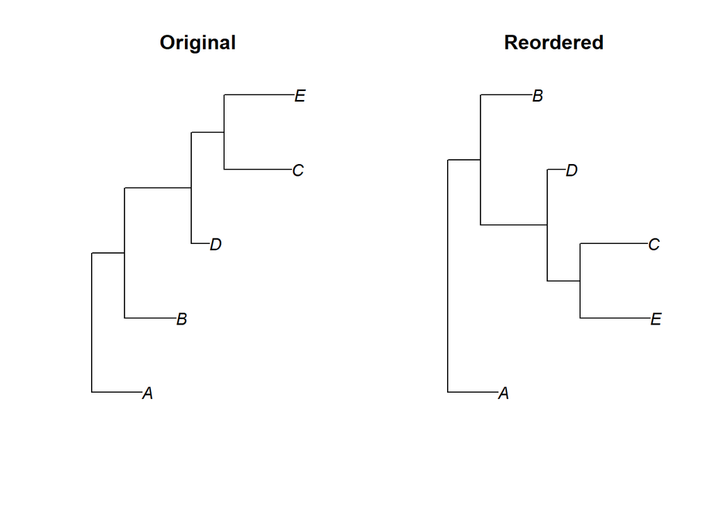

```r
new_tree <- tree_reorder(
    tree = my_tree,
    labels = target_order
)

par(mfrow = c(1,2))

plot(my_tree)
title("Original")

plot(new_tree)
title("Reordered")
```

## Genetic optimization

For the genetic algorithm, instead of treating the final tip order as the chromosome (which could easily produce invalid tree structures), the key idea is to encode only the rotations of the internal nodes. In a rooted binary tree with N tips, there are exactly N−1 internal nodes, and each internal node has only two possible orientations: it can either remain in its current orientation or have its left and right child subtrees swapped. Importantly, swapping these subtrees changes only the visual arrangement of the tips—it does not change the tree topology, branch lengths, or evolutionary relationships.

Therefore, the chromosome is represented as a binary vector of length N−1, where each gene corresponds to one internal node:

0 = leave the node unchanged. 1 = rotate (flip) the node.

This encoding guarantees that every chromosome always represents a valid version of the original tree, eliminating the possibility of generating biologically invalid trees during the evolutionary search.

The fitness function then performs three main steps:

Takes a binary chromosome as input. Applies the specified rotations to the original tree. Computes the resulting tip order and compares it with the desired target order.

```r
###############################################################
# Genetic Algorithm to Optimize Phylogenetic Tree Tip Ordering
#
# Goal:
#   Find the combination of internal-node rotations that makes
#   the displayed tip order as close as possible to a user-
#   specified target ordering.
#
# Representation:
#   Each chromosome is a binary vector.
#
#       0 = Do NOT rotate the corresponding internal node
#       1 = Rotate the corresponding internal node
#
# A tree with N internal nodes therefore has N binary genes.
###############################################################
# install.packages("GA")

library(ape)
library(GA)
```

```r
###############################################################
# Example tree
###############################################################

set.seed(42)

# Generate a random rooted phylogenetic tree with 10 taxa
my_tree <- rtree(10)

# Desired tip order
target_order <- c(
  "t10","t9","t8","t7","t6",
  "t5","t4","t3","t2","t1"
)

###############################################################
# Function: Extract the CURRENT displayed tip order
#
# ape does NOT provide a function that directly returns the
# plotting order after arbitrary rotations.
#
# Therefore we recursively traverse the tree from the root,
# always visiting the left child before the right child.
#
# This produces the same ordering used when plotting a standard
# rectangular phylogram.
###############################################################

get_tip_order <- function(tree){

  edge <- tree$edge

  nTip <- length(tree$tip.label)

  root <- nTip + 1

  visit <- function(node){

    children <- edge[edge[,1] == node, 2]

    labels <- character(0)

    for(child in children){

      if(child <= nTip){

        labels <- c(labels, tree$tip.label[child])

      }else{

        labels <- c(labels, visit(child))

      }

    }

    labels

  }

  visit(root)

}

###############################################################
# Fitness Function
#
# GA attempts to MAXIMIZE this score.
#
# We first:
#
#   1) Rotate the nodes indicated by the chromosome.
#   2) Compute the resulting displayed tip order.
#   3) Compare it with the desired ordering.
#
# A perfect match gives a fitness of 0.
# Worse matches become increasingly negative.
###############################################################

evaluate_tree_rotation <- function(chromosome,
                                   tree,
                                   target){

  modified_tree <- tree

  nTip <- length(tree$tip.label)

  node_ids <- (nTip + 1):(nTip + tree$Nnode)

  #############################################################
  # Apply chromosome
  #############################################################

  for(i in seq_along(chromosome)){

    if(chromosome[i] == 1){

      modified_tree <- ape::rotate(
        modified_tree,
        node_ids[i]
      )

    }

  }

  #############################################################
  # Obtain current displayed tip order
  #############################################################

  current_order <- get_tip_order(modified_tree)

  #############################################################
  # Fitness
  #
  # match() returns the position of each current tip within the
  # target ordering.
  #
  # Smaller positional differences mean a better ordering.
  #############################################################

  fitness <-
    -sum(abs(
      match(current_order, target) -
      seq_along(target)
    ))

  return(fitness)

}
```

Since the chromosome is simply a binary string of 0s and 1s, the GA package can be used directly with type = “binary”. During the optimization, the genetic algorithm evolves a population of candidate rotation patterns using selection, crossover, and mutation to search for increasingly better tip orderings. Once the algorithm terminates, the best chromosome found represents the optimal (or near-optimal) combination of internal-node rotations. Applying this chromosome to the original tree produces the reordered tree, whose tip arrangement most closely matches the desired target ordering while preserving the original tree topology.

```r
###############################################################
# Number of genes
#
# One binary gene per internal node.
###############################################################

n_bits <- my_tree$Nnode

###############################################################
# Run the Genetic Algorithm
###############################################################

ga_result <- ga(

  type = "binary",

  fitness = function(chr)
    evaluate_tree_rotation(
      chr,
      my_tree,
      target_order
    ),

  nBits = n_bits,

  popSize = 50,

  maxiter = 100,

  pmutation = 0.10,

  elitism = 2,

  monitor = gaMonitor

)
```

```
## GA | iter = 1 | Mean = -33.48 | Best = -16.00
## GA | iter = 2 | Mean = -30.88 | Best = -16.00
## GA | iter = 3 | Mean = -31 | Best = -16
## GA | iter = 4 | Mean = -28.08 | Best = -16.00
## GA | iter = 5 | Mean = -26.6 | Best = -16.0
## GA | iter = 6 | Mean = -23.4 | Best = -16.0
## GA | iter = 7 | Mean = -23.48 | Best = -14.00
## GA | iter = 8 | Mean = -24.6 | Best = -14.0
## GA | iter = 9 | Mean = -22.92 | Best = -14.00
## GA | iter = 10 | Mean = -22.52 | Best = -14.00
## GA | iter = 11 | Mean = -22.84 | Best = -14.00
## GA | iter = 12 | Mean = -21.56 | Best = -14.00
## GA | iter = 13 | Mean = -20.44 | Best = -14.00
## GA | iter = 14 | Mean = -20.96 | Best = -14.00
## GA | iter = 15 | Mean = -21.56 | Best = -14.00
## GA | iter = 16 | Mean = -21.36 | Best = -14.00
## GA | iter = 17 | Mean = -20.4 | Best = -14.0
## GA | iter = 18 | Mean = -19 | Best = -14
## GA | iter = 19 | Mean = -17.96 | Best = -14.00
## GA | iter = 20 | Mean = -17.8 | Best = -14.0
## GA | iter = 21 | Mean = -17.72 | Best = -14.00
## GA | iter = 22 | Mean = -18.44 | Best = -14.00
## GA | iter = 23 | Mean = -18.44 | Best = -14.00
## GA | iter = 24 | Mean = -18.72 | Best = -14.00
## GA | iter = 25 | Mean = -17.64 | Best = -14.00
## GA | iter = 26 | Mean = -18.6 | Best = -14.0
## GA | iter = 27 | Mean = -18.72 | Best = -14.00
## GA | iter = 28 | Mean = -19.16 | Best = -14.00
## GA | iter = 29 | Mean = -19.04 | Best = -14.00
## GA | iter = 30 | Mean = -18.56 | Best = -14.00
## GA | iter = 31 | Mean = -18.16 | Best = -14.00
## GA | iter = 32 | Mean = -18.2 | Best = -14.0
## GA | iter = 33 | Mean = -17.52 | Best = -14.00
## GA | iter = 34 | Mean = -17.52 | Best = -14.00
## GA | iter = 35 | Mean = -17.32 | Best = -14.00
## GA | iter = 36 | Mean = -16.68 | Best = -14.00
## GA | iter = 37 | Mean = -16.56 | Best = -14.00
## GA | iter = 38 | Mean = -16.88 | Best = -14.00
## GA | iter = 39 | Mean = -16.6 | Best = -14.0
## GA | iter = 40 | Mean = -16.96 | Best = -14.00
```

[output cut: 45 more lines]

```
## GA | iter = 86 | Mean = -15.96 | Best = -14.00
## GA | iter = 87 | Mean = -15.88 | Best = -14.00
## GA | iter = 88 | Mean = -15.92 | Best = -14.00
## GA | iter = 89 | Mean = -16.04 | Best = -14.00
## GA | iter = 90 | Mean = -17.68 | Best = -14.00
## GA | iter = 91 | Mean = -17.04 | Best = -14.00
## GA | iter = 92 | Mean = -17 | Best = -14
## GA | iter = 93 | Mean = -17.24 | Best = -14.00
## GA | iter = 94 | Mean = -16.64 | Best = -14.00
## GA | iter = 95 | Mean = -16.96 | Best = -14.00
## GA | iter = 96 | Mean = -17 | Best = -14
## GA | iter = 97 | Mean = -17.04 | Best = -14.00
## GA | iter = 98 | Mean = -17.6 | Best = -14.0
## GA | iter = 99 | Mean = -17.28 | Best = -14.00
## GA | iter = 100 | Mean = -16 | Best = -14
```

```r
###############################################################
# Best chromosome found
###############################################################

best_chromosome <- as.vector(
  ga_result@solution[1,]
)

###############################################################
# Apply the winning chromosome
###############################################################

best_tree <- my_tree

node_ids <-
  (length(my_tree$tip.label)+1):
  (length(my_tree$tip.label)+my_tree$Nnode)

for(i in seq_along(best_chromosome)){

  if(best_chromosome[i] == 1){

    best_tree <- ape::rotate(
      best_tree,
      node_ids[i]
    )

  }

}

###############################################################
# Display Results
###############################################################

cat("\nTarget order:\n")
```

```
##
## Target order:
```

```r
print(target_order)
```

```
##  [1] "t10" "t9"  "t8"  "t7"  "t6"  "t5"  "t4"  "t3"  "t2"  "t1"
```

```r
cat("\nBest obtained order:\n")
```

```
##
## Best obtained order:
```

```r
print(get_tip_order(best_tree))
```

```
##  [1] "t10" "t8"  "t9"  "t7"  "t4"  "t1"  "t6"  "t3"  "t2"  "t5"
```

```r
cat("\nFitness:\n")
```

```
##
## Fitness:
```

```r
print(max(ga_result@fitness))
```

```
## [1] -14
```

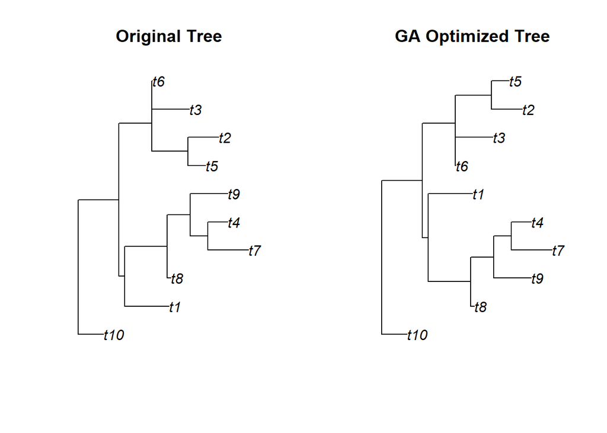

```r
###############################################################
# Plot comparison
###############################################################

par(mfrow = c(1,2))

plot(my_tree,
     main = "Original Tree")

plot(best_tree,
     main = "GA Optimized Tree")
```

## Bonus

Now let’s take this a step further, we can attempt to solve a tree optimization problem using a Monte Carlo optimization strategy (MCMC/simulated annealing style) where it searches through possible tree states to find one that best matches a desired tip ordering. In simple words, the objective is to search through many possible trees (including different evolutionary structures) and find one whose tip arrangement is closest to the target.

```r
# install.packages(c("ape", "phangorn"))


library(ape)
library(phangorn)

# Set up a reproducible example
set.seed(42)
my_tree <- rtree(15)
target_order <- sample(my_tree$tip.label) # Random target for demonstration
```

“Energy” is the mathematical distance between the tree’s current visual layout and the desired target order. It will use the Sum of Squared Rank Differences (similar to Spearman’s rank correlation), which is highly stable for MCMC gradients. At each step of the Markov chain, it proposes a random change to the tree. So it defines two distinct moves: a visual rotation (Type A) and a structural topology shift (Type B).

```r
calculate_energy <- function(tree, target) {
  # Extract the top-to-bottom visual plotting order of the tips
  is_tip <- tree$edge[,2] <= Ntip(tree)
  current_order <- tree$tip.label[tree$edge[is_tip, 2]]

  # Find the rank (position) of each current tip in the target list
  current_ranks <- match(current_order, target)
  target_ranks <- 1:length(target)

  # Calculate the squared distance between current positions and target positions
  # Lower energy = better match. 0 = perfect match.
  energy <- sum((current_ranks - target_ranks)^2)

  return(energy)
}
# Move Type A: Visual Rotation
# Rotates the left/right branches of a single random internal node.
propose_rotation <- function(tree) {
  num_tips <- Ntip(tree)
  internal_nodes <- (num_tips + 1):(num_tips + tree$Nnode)
  node_to_rotate <- sample(internal_nodes, 1)

  return(rotate(tree, node_to_rotate))
}

# Move Type B: Structural Topology Shift (NNI)
# Performs a Nearest Neighbor Interchange to slightly alter evolutionary history.
propose_topology_shift <- function(tree) {
  # phangorn::nni generates all possible NNI neighbors for the tree
  neighbors <- nni(tree)

  # Randomly sample exactly one neighbor from the multiPhylo object
  random_neighbor <- sample(neighbors, size = 1)[[1]]
  return(random_neighbor)
}
run_mcmc_sampler <- function(start_tree, target, iterations = 2000,
                             start_temp = 100, cooling_rate = 0.99,
                             topology_prob = 0.3) {

  current_tree <- start_tree
  current_energy <- calculate_energy(current_tree, target)

  best_tree <- current_tree
  best_energy <- current_energy

  temperature <- start_temp
  energy_history <- numeric(iterations)

  for (i in 1:iterations) {
    # 1. Choose a proposal mechanism
    # We prioritize rotations, but allow topology shifts based on topology_prob
    if (runif(1) < topology_prob) {
      proposed_tree <- propose_topology_shift(current_tree)
    } else {
      proposed_tree <- propose_rotation(current_tree)
    }

    # 2. Calculate the energy of the proposed state
    proposed_energy <- calculate_energy(proposed_tree, target)
    delta_energy <- proposed_energy - current_energy

    # 3. Metropolis-Hastings Acceptance Criterion
    # Always accept if it's an improvement (delta_energy < 0)
    # If worse, accept with a probability proportional to the temperature
    acceptance_prob <- exp(-delta_energy / temperature)

    if (delta_energy < 0 || runif(1) < acceptance_prob) {
      current_tree <- proposed_tree
      current_energy <- proposed_energy

      # Track the absolute best state found during the chain
      if (current_energy < best_energy) {
        best_tree <- current_tree
        best_energy <- current_energy
      }
    }

    # Record history and cool the system down
    energy_history[i] <- current_energy
    temperature <- temperature * cooling_rate
  }

  return(list(
    optimized_tree = best_tree,
    best_energy = best_energy,
    history = energy_history
  ))
}
```

Run the sampler and visualize the results. Because this is a stochastic process, plotting the energy history is crucial—it proves that the algorithm successfully converged on a minimum rather than getting stuck.

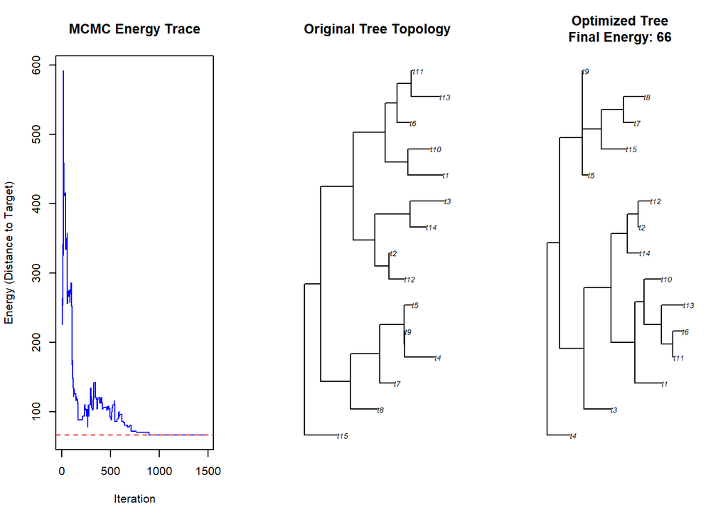

```r
# Run the sampler
# Note: Increasing 'topology_prob' allows the tree structure to break more aggressively
# to match the target. Setting it to 0.0 makes it purely a visual rotation optimizer.
mcmc_results <- run_mcmc_sampler(my_tree, target_order,
                                 iterations = 1500,
                                 start_temp = 50,
                                 cooling_rate = 0.995,
                                 topology_prob = 0.4)

# ----------------- Visualizations ----------------- #
par(mfrow = c(1, 3))

# 1. The Energy Trace (Diagnostics)
plot(mcmc_results$history, type = "l", col = "blue",
     main = "MCMC Energy Trace",
     xlab = "Iteration", ylab = "Energy (Distance to Target)")
abline(h = mcmc_results$best_energy, col = "red", lty = 2)

# 2. Original Tree
plot(my_tree, main = "Original Tree Topology")

# 3. Optimized Joint-Space Tree
plot(mcmc_results$optimized_tree,
     main = paste("Optimized Tree\nFinal Energy:", mcmc_results$best_energy))
```

Now for For only visual ordering, we could set topology_prob = 0 Then it becomes: Only rotations + MCMC search although even that is overkill because rotateConstr() already solves the problem.

We could also make it a more elegant solution by applying MCMC to actual DNA alignment data! Combining two different concepts here: the Joint Topology-Rotation Space (which I used previously for visual layout optimization) and the question “Which evolutionary tree best explains my DNA alignment?” (which is the core of Bayesian Phylogenetic Inference).

```r
# ---------------------------------------------------------
# 1. GENERATE DUMMY DNA DATA
# ---------------------------------------------------------
set.seed(123)
# Create a true evolutionary tree with 8 species
true_tree <- rtree(8)
# Simulate a DNA alignment of 500 base pairs based on this tree
dna_alignment <- simSeq(true_tree, l = 500, type = "DNA")

# Create a random starting tree for the MCMC (so it has to work to find the truth)
start_tree <- rtree(8, tip.label = true_tree$tip.label)

# ---------------------------------------------------------
# 2. LIKELIHOOD FUNCTION
# ---------------------------------------------------------
# Calculates how well a specific tree explains the DNA data
evaluate_dna_likelihood <- function(tree, alignment) {
  # The pml() function calculates the likelihood of the tree given the data
  # using a standard Jukes-Cantor DNA substitution model
  fit <- pml(tree, data = alignment)
  return(fit$logLik)
}

# ---------------------------------------------------------
# 3. MCMC SAMPLER FUNCTION
# ---------------------------------------------------------
run_phylogenetic_mcmc <- function(start_tree, alignment, iterations = 500) {

  current_tree <- start_tree
  current_ll <- evaluate_dna_likelihood(current_tree, alignment)

  # Vectors to store the history of the chain
  ll_history <- numeric(iterations)
  sampled_trees <- vector("list", iterations)

  cat("Running MCMC...\n")

  for(i in 1:iterations) {
    # Propose a new topology using Nearest Neighbor Interchange (NNI)
    nni_neighbors <- nni(current_tree)
    # Randomly pick one of the NNI neighbors
    proposed_tree <- nni_neighbors[[sample(length(nni_neighbors), 1)]]

    # Calculate likelihood of the proposed tree
    proposed_ll <- evaluate_dna_likelihood(proposed_tree, alignment)

    # Calculate Metropolis-Hastings acceptance ratio (Log scale)
    log_alpha <- proposed_ll - current_ll

    # Accept or Reject
    # (If log_alpha > 0, it's an improvement and log(runif) will always be less than it)
    if (log(runif(1)) < log_alpha) {
      current_tree <- proposed_tree
      current_ll <- proposed_ll
    }

    # Record the state of the chain
    ll_history[i] <- current_ll
    sampled_trees[[i]] <- current_tree

    # Print progress
    if (i %% 100 == 0) cat("Iteration:", i, "| Log-Likelihood:", round(current_ll, 2), "\n")
  }

  # Format output
  class(sampled_trees) <- "multiPhylo"
  return(list(trees = sampled_trees, likelihoods = ll_history))
}
```

execute the chain:

```r
# Run the MCMC for 500 iterations
# (In real research, this would be 1,000,000+ iterations!)
mcmc_results <- run_phylogenetic_mcmc(start_tree, dna_alignment, iterations = 500)
```

```
## Running MCMC...
## Iteration: 100 | Log-Likelihood: -5302.9
## Iteration: 200 | Log-Likelihood: -5301.34
## Iteration: 300 | Log-Likelihood: -5302.9
## Iteration: 400 | Log-Likelihood: -5302.9
## Iteration: 500 | Log-Likelihood: -5301.34
```

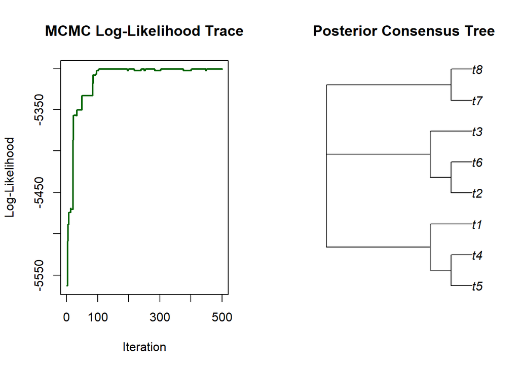

```r
# Set the plotting layout
par(mfrow = c(1, 2))

# ----------------- Visualizations ----------------- #

# 1. The MCMC Trace Plot
# You should see the line climb rapidly and then plateau,
# indicating it has found the maximum likelihood topological space.
plot(mcmc_results$likelihoods, type = "l", col = "darkgreen", lwd = 2,
     main = "MCMC Log-Likelihood Trace",
     xlab = "Iteration", ylab = "Log-Likelihood")

# 2. The Consensus Tree
# We discard the first 20% of iterations as "burn-in"
burn_in <- 100
valid_trees <- mcmc_results$trees[burn_in:500]

# Calculate the consensus tree from the posterior distribution
posterior_consensus <- consensus(valid_trees, p = 0.5)

plot(posterior_consensus, main = "Posterior Consensus Tree")
```